# Simple Regression: Coefficient of Determination

## Extrapolation

- Within the range of the observed values of the predictor variable, we can reasonably use the regression equation to make predictions for the response variable.
- However, to do so outside the range, which is called **Extrapolation**, may not be reasonable because the linear relationship between the predictor and response variables may not hold here.
- To predict the price of an 11-year old car, $\hat{y}=195.47-20.26 (11)=-27.39$ or $ 2739, this result is unrealistic as no one is going to pay us $2739 to take away their 11-year old car.

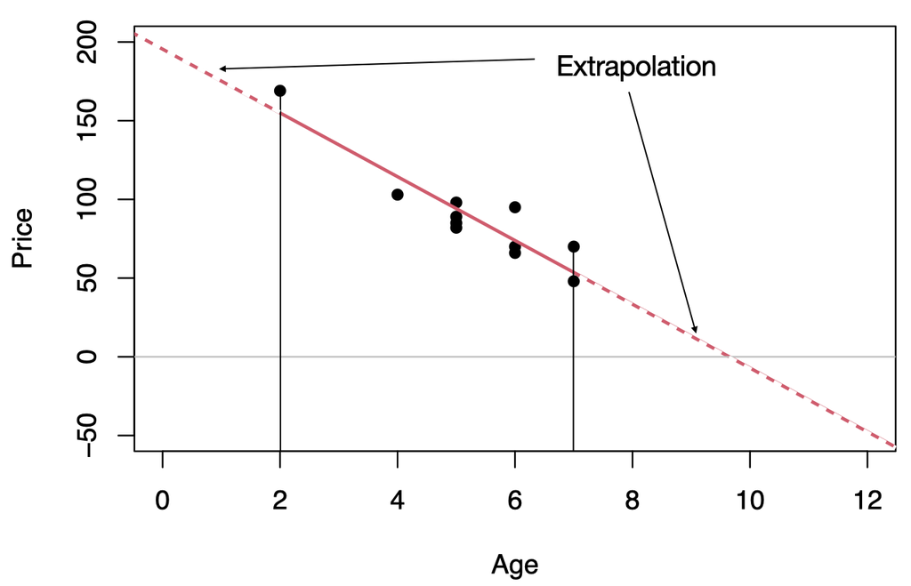

## Outliers and influential observations

- Recall that an **outlier** is an observation that lies outside the overall pattern of the data. In the context of regression, an outlier is a data point that lies far from the regression line, relative to the other data points.
- An **influential observation** is a data point whose removal causes the regression equation (and line) to change considerably.
- From the scatterplot, it seems that the data point (2,169) might be an influential observation. Removing that data point and recalculating the regression equation yields $\hat{y}=160.33-14.24\;x$.

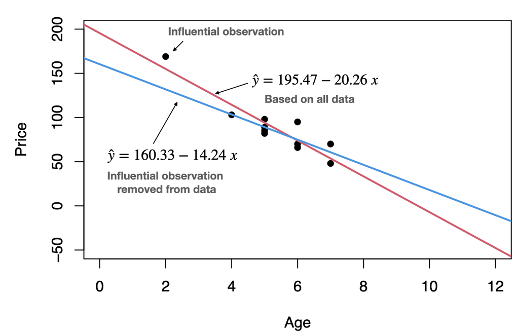

## Coefficient of determination

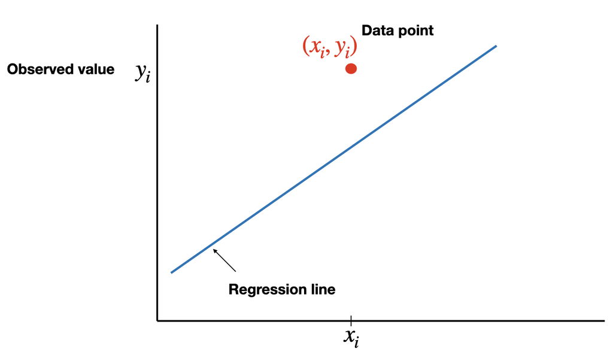

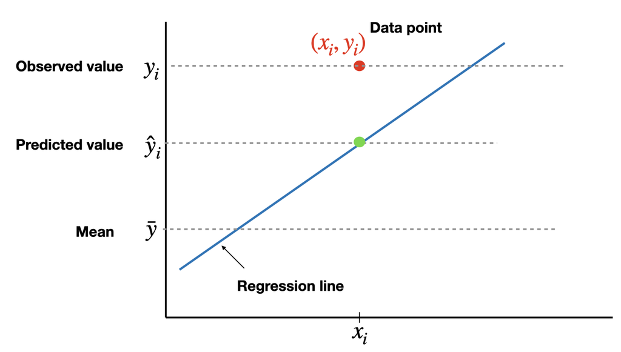

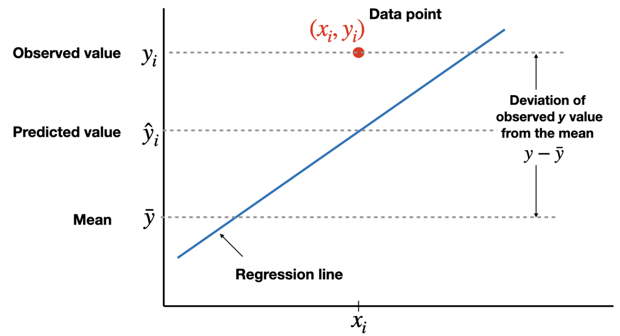

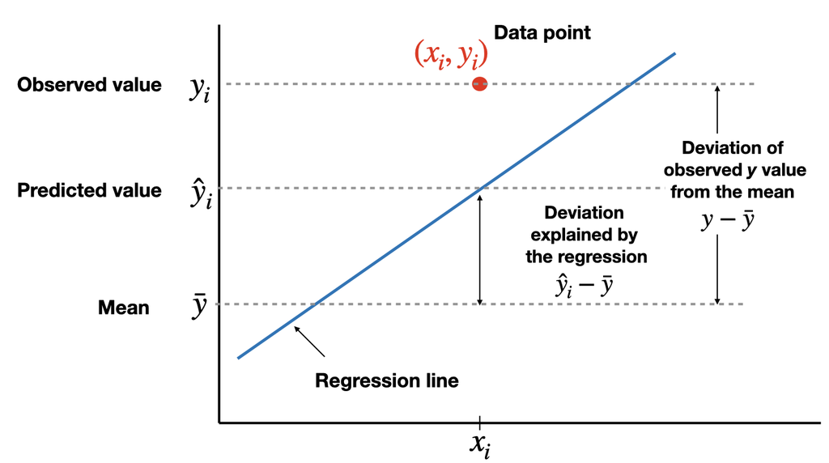

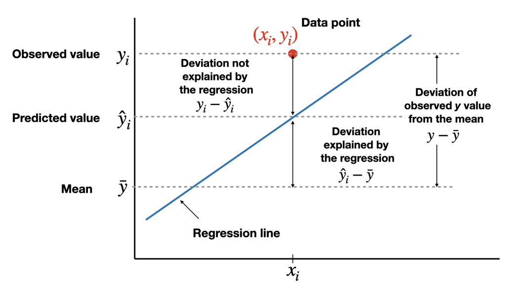

- The total variation in the observed values of the response variable, $SST=\sum(y_i-\bar{y})^2$, can be partitioned into two components:
  - The variation in the observed values of the response variable explained by the regression: $SSR=\sum(\hat{y}_i-\bar{y})^2$
  - The variation in the observed values of the response variable not explained by the regression: $SSE=\sum(y_i-\hat{y}_i)^2$
- The coefficient of determination, $R^2$ (or $R$-square), is the proportion of the variation in the observed values of the response variable explained by the regression, which is given by
  $$R^2=\frac{SSR}{SST}=\frac{SST-SSE}{SST}=1-\frac{SSE}{SST}$$
  where $SST=SSR+SSE$. $R^2$ is a descriptive measure of the utility of the regression equation for making prediction.
- The coefficient of determination $R^2$ always lies between 0 and 1. A value of $R^2$ near 0 suggests that the regression equation is not very useful for making predictions, whereas a value of $R^2$ near 1 suggests that the regression equation is quite useful for making predictions.
- For a simple linear regression (one independent variable) ONLY, $R^2$ is the square of Pearson correlation coefficient, $r$.
- $\text{Adjusted}\;R^2$ is a modification of $R^2$ which takes into account the number of independent variables, say $k$. In a simple linear regression $k=1$. Adjusted-$R^2$ increases only when a significant related independent variable is added to the model. Adjusted-$R^2$ has a crucial role in the process of model building. Adjusted-$R^2$ is given by
  $$\text{Adjusted-}R^2=1-(1-R^2)\frac{n-1}{n-k-1}$$

## Notation used in regression

| Quantity | Defining formula | Computing formula |
| --- | --- | --- |
| $S_{xx}$ | $\sum (x_i-\bar{x})^2$ | $\sum x^2_i - n \bar{x}^2$ |
| $S_{xy}$ | $\sum (x_i-\bar{x})(y_i-\bar{y})$ | $\sum x_i y_i - n \bar{x}\bar{y}$ |
| $S_{yy}$ | $\sum (y_i-\bar{y})^2$ | $\sum y^2_i - n \bar{y}^2$ |

where $\bar{x}=\frac{\sum x_i}{n}$ and $\bar{y}=\frac{\sum y_i}{n}$. And,

$$SST=S_{yy},\;\;\;
SSR=\frac{S^2_{xy}}{S_{xx}},\;\;\; SSE=S_{yy}-\frac{S^2_{xy}}{S_{xx}}$$
and $SST=SSR+SSE$.